# Lab. 2 — Regression Analysis and Lab.

May 6th, 2024

# Multiple Linear Regression (Ch 3, 5, 7)

- A **multiple linear regression model** with $n$ observations and $k$ parameters can be represented as
  $$\mathbf{y} = \mathbf{X} \boldsymbol\beta +
  \boldsymbol\epsilon,$$

  where $\mathbf{X}\in\mathbb{R}^{n\times (k+1)}$ and $\boldsymbol{\beta} = (\beta_0,\dots,\beta_k)^\top$.
- In the previous lab session, we learned that `lm(y ~ x, data = data.name)` conducts a simple linear regression of the model $y = \beta_0 + \beta_1 x + \epsilon$. The first argument (`y ~ model`) is called `formula`, and we can specify other types of linear regression using this argument, e.g., multiple linear regression, polynomial regression, etc.
  - Terms in the `model` (right-hand side of the `formula`) should be separated by `+` operators. Specify the model $y = \beta_0 + \beta_1 x_1 + \beta_2 x_2 + \epsilon$ by `y ~ x1 + x2`.
  - `a:b` is interpreted as an interaction term. For example, specify the model $y = \beta_0 + \beta_1 x_1 + \beta_2 x_2 + \beta_3 x_1x_2 + \epsilon$ by `y ~ x1 + x2 + x1:x2`.
  - `a*b` is a short-hand for `a + b + a:b`. That is, `y ~ x1 + x2 + x1:x2` is equivalent to `y ~ x1*x2`.
  - `a*b-b` is interpreted as `a + a:b`. For example, specify the model $y = \beta_0 + \beta_1 x_1 + \beta_2x_1x_2 + \epsilon$ by `y ~ x1*x2 - x2` (or `y ~ x1 + x1:x2`)
  - The intercept term can be specified using `1`, and can be removed by `-1`.

> **Caution: When used inside the `model` part of the `formula` argument (right-hand side of the `formula`), `+`, `-`, `*`, `/`, `^` are interpreted as formula operators. Hence, to use them as arithmetical operators, they must be used with the `I()` function.**

| Model | Formula |
| --- | --- |
| $y = \beta_0 + \beta_1 x_1 + \epsilon$ | `y ~ x1` |
| $y = \beta_0 + \epsilon$ | `y ~ 1` |
| $y = \beta_1 x_1 + \epsilon$ | `y ~ x1 - 1` |
| $y = \beta_0 + \beta_1 x_1 + \beta_2 x_2 + \epsilon$ | `y ~ x1 + x2` |
| $y = \beta_0 + \beta_1(x_1 - x_2) + \epsilon$ | `y ~ I(x1-x2)` |
| $y = \beta_0 + \beta_1(1/x_1) + \epsilon$ | `y ~ I(1/x1)` |
| $y = \beta_0 + \beta_1 x_1 + \beta_2 x_1^2 + \epsilon$ | `y ~ x1 + I(x1^2)` |
| $\log(y) = \beta_0 + \beta_1 \log(x_1) + \epsilon$ | `log(y) ~ log(x1)` |
| $\sqrt{y} = \beta_0 + \beta_1 x_1 + \epsilon$ | `sqrt(y) ~ x1` |
| $1/y = \beta_0 +\beta_1 x_1 + \epsilon$ | `1/y ~ x1` |

- We use the ‘Delivery time data’ (example 3.1, page 76). A soft drink bottler is interested in predicting the amount of time required by the route driver to service the vending machines in an outlet (`time`; y). To do this, the bottler considers two variables: (1) number of cases of product stocked (`case`; x1), and (2) distance walked by the route driver (`distance`; x2). Hence, $n=25$ and $k=2$ in this example ($p=k+1=3$).

```r
deliver <- read.csv("ex3.1.csv")
colnames(deliver) <- c("obs", "time", "case", "distance")
head(deliver)
```

```
##   obs  time case distance
## 1   1 16.68    7      560
## 2   2 11.50    3      220
## 3   3 12.03    3      340
## 4   4 14.88    4       80
## 5   5 13.75    6      150
## 6   6 18.11    7      330
```

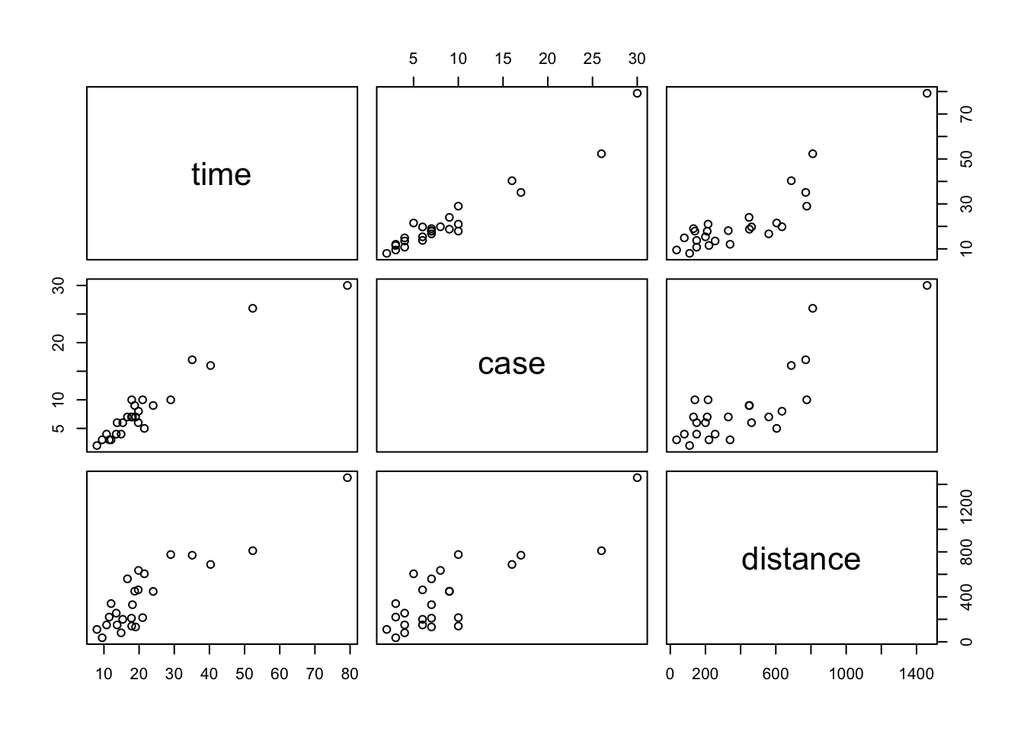

```r
plot(deliver[,2:4]) # scatterplot matrix
```

- We consider the multiple linear regression model
  $${\tt time} = \beta_0 + \beta_1 {\tt case} + \beta_2 {\tt distance} +
  \epsilon.$$

```r
lmfit.full <- lm(time ~ case + distance, data=deliver)
summary(lmfit.full)
```

```
##
## Call:
## lm(formula = time ~ case + distance, data = deliver)
##
## Residuals:
##     Min      1Q  Median      3Q     Max
## -5.7880 -0.6629  0.4364  1.1566  7.4197
##
## Coefficients:
##             Estimate Std. Error t value Pr(>|t|)
## (Intercept) 2.341231   1.096730   2.135 0.044170 *
## case        1.615907   0.170735   9.464 3.25e-09 ***
## distance    0.014385   0.003613   3.981 0.000631 ***
## ---
## Signif. codes:  0 '***' 0.001 '**' 0.01 '*' 0.05 '.' 0.1 ' ' 1
##
## Residual standard error: 3.259 on 22 degrees of freedom
## Multiple R-squared:  0.9596, Adjusted R-squared:  0.9559
## F-statistic: 261.2 on 2 and 22 DF,  p-value: 4.687e-16
```

- From the result above, we can see that
  - $\hat{y} = 2.34123 + 1.61591 x_1 + 0.01439 x_2$.
  - $\hat\sigma^2 = \frac{SS_E}{n-p} = MS_E = \color{red}{3.259^2} = 10.621$.
  - This model is significant (i.e., $H_0: \beta_1 = \beta_2 = 0$ is rejected) because p-value of the F-test is $4.687\times 10^{-16}$.
  - $R^2 = 0.9596$ and $R^2_{adj} = 0.9559$.
  - Individual regression coefficients are significant on level $\alpha = 0.05$. Specifically, the p-value for the t-test on $H_0: \beta_1 = 0$ is $3.25\times 10^{-9}$ and the p-value for the t-test on $H_0: \beta_2 = 0$ is $0.000631$.
- To find out what kinds of information are stored in `lmfit.full` and `summary(lmfit.full)`, use the `names()` function.

```r
names(lmfit.full)
lmfit.full$residuals # e
names(summary(lmfit.full))
summary(lmfit.full)$r.squared # R^2
predict(lmfit.full) # y.hat; or use [lmfit.full$fitted.values]
```

## Hypothesis Testing in Multiple Linear Regression

- To conduct tests for more general hypotheses, we use the extra sum of squares method (`anova()` function).

### Tests on individual regression coefficients and subsets of coefficients

- Consider two linear regression models,
  $$\mathbf{y} = \mathbf{X}_1 \boldsymbol\beta_1 +
  \mathbf{X}_2 \boldsymbol\beta_2 + \boldsymbol\epsilon \tag*{(Full
  Model)}$$
  and
  $$\mathbf{y} =
  \mathbf{X}_1 \boldsymbol\beta_1 + \boldsymbol\epsilon \tag*{(Reduced
  Model)}.$$
  If one wants to test
  $$H_0:
  \boldsymbol\beta_2 = \mathbf{0} \quad \text{v.s.} \quad H_1:
  \boldsymbol\beta_2 \neq \mathbf{0} ,$$
  one can use the fact that
  $$\frac{SS_R (\boldsymbol\beta_2 |
  \boldsymbol\beta_1)/df_1}{SS_E(Full)/df_2} \overset{H_0}{\sim} F(df_1,
  df_2).$$
- `anova(reduced_model, full_model)` conducts the extra sum of squares test.

> **Caution: Order of the arguments of the `anova()` function is important! The former model should be a *nested* model of the latter to make sense.**
- We want to test $H_0: \beta_2 = 0$ in the model
  $${\tt time} = \beta_0 + \beta_1 {\tt case} + \beta_2 {\tt distance} +
  \epsilon.$$

```r
lmfit.full <- lm(time ~ case + distance, data=deliver)
lmfit.reduced <- lm(time ~ case, data=deliver)
anova(lmfit.reduced, lmfit.full) # is distance significant?
```

```
## Analysis of Variance Table
##
## Model 1: time ~ case
## Model 2: time ~ case + distance
##   Res.Df    RSS Df Sum of Sq      F    Pr(>F)
## 1     23 402.13
## 2     22 233.73  1     168.4 15.851 0.0006312 ***
## ---
## Signif. codes:  0 '***' 0.001 '**' 0.01 '*' 0.05 '.' 0.1 ' ' 1
```

- Interpretation:
  - First row: information of the first model (reduced model) / second row: info of the second model (full model)
  - `Res.Df`: Residual degree of freedom
  - `RSS`: $SS_E$. Hence, $SS_E(R) = 402.13$ (with df = 23), $SS_E(F) = 233.73$ (with df = 22).
  - `Df`, `Sum of Sq`: changes in the `Res.Df` and `RSS`. Hence, $168.4$ denotes $SS_E(R) - SS_E(F) = SS_R(F) - SS_R(R) = SS_R(\beta_2 | \beta_1, \beta_0)$.
  - `F`: $F_0$ of the test specified above.
  - `Pr(>F)`: p-value of the test. Here, we reject $H_0$ at $\alpha = 0.05$, which implies that **distance is significant**.

### Testing the general linear hypothesis

- Can you test $H_0: \beta_1 = \beta_2$ from the full model?

$$y = \beta_0 + \beta_1 x_1 + \beta_2 x_2
+ \epsilon \tag*{(Full Model)}$$
$$y
= \beta_0 + \beta_1(x_1+x_2) + \epsilon \tag*{(Reduced
Model)}$$

```r
anova(lm(time ~ I(case + distance), data = deliver),
      lm(time ~ case + distance, data = deliver)) # reject null
```

```
## Analysis of Variance Table
##
## Model 1: time ~ I(case + distance)
## Model 2: time ~ case + distance
##   Res.Df     RSS Df Sum of Sq      F    Pr(>F)
## 1     23 1136.63
## 2     22  233.73  1    902.89 84.985 5.192e-09 ***
## ---
## Signif. codes:  0 '***' 0.001 '**' 0.01 '*' 0.05 '.' 0.1 ' ' 1
```

### ANOVA table

- Consider the two models:
  $$y = \beta_0 +
  \beta_1x_1 + \beta_2x_2 + \epsilon \tag*{(Full Model)}$$
  $$y = \beta_0 + \epsilon \tag*{(Reduced
  Model)}$$

```r
lmfit.full <- lm(time ~ case + distance, data=deliver)
lmfit.reduce <- lm(time ~ 1, data = deliver)
anova(lmfit.reduce, lmfit.full)
```

```
## Analysis of Variance Table
##
## Model 1: time ~ 1
## Model 2: time ~ case + distance
##   Res.Df    RSS Df Sum of Sq      F    Pr(>F)
## 1     24 5784.5
## 2     22  233.7  2    5550.8 261.24 4.687e-16 ***
## ---
## Signif. codes:  0 '***' 0.001 '**' 0.01 '*' 0.05 '.' 0.1 ' ' 1
```

- $5784.5$ denote $SS_E(R) = \sum_{i=1}^n(y_i - \hat{\beta}_0)^2 = \sum_{i=1}^n(y_i - \bar{y})^2 = SS_T$.
- Hence, $233.7 = SS_E(F)$ and $5550.8 = SS_R(F)$.
- An ANOVA table of the full model can be constructed.

[output not shown]

- Observe that $F_0$ is equivalent to the result from `summary(lmfit.full)`.

## Confidence Intervals in Multiple Regression

### Confidence intervals on the regression coefficients

- As in the simple linear regression, use `confint` function to compute confidence interval of the regression coefficients.
  $$100(1-\alpha)\%\text{ confidence interval of }\beta_j: \hat\beta_j \pm
  t_{\alpha/2, n-(k+1)}se(\hat\beta_j)$$

```r
confint(lmfit.full) # 95% confidence interval
```

```
##                   2.5 %     97.5 %
## (Intercept) 0.066751987 4.61571030
## case        1.261824662 1.96998976
## distance    0.006891745 0.02187791
```

### Confidence interval of the mean response / Prediction of new observations

```r
predict(lmfit.full, data.frame(case = c(5, 10, 15), distance=c(700, 500, 300)))
```

```
##        1        2        3
## 20.49015 25.69272 30.89529
```

```r
predict(lmfit.full, data.frame(case = c(5, 10, 15), distance=c(700, 500, 300)), interval="confidence")
```

```
##        fit      lwr      upr
## 1 20.49015 16.86711 24.11318
## 2 25.69272 24.28182 27.10361
## 3 30.89529 27.67622 34.11436
```

```r
predict(lmfit.full, data.frame(case = c(5, 10, 15), distance=c(700, 500, 300)), interval="predict")
```

```
##        fit      lwr      upr
## 1 20.49015 12.82070 28.15959
## 2 25.69272 18.78731 32.59812
## 3 30.89529 23.40820 38.38237
```

## Transformations

- One can transform the variables for variance stabilization or to linearize the model.
- Using the ‘Windmill data’ (example 5.2, page 184), we consider the following three models ($y$: DC output from the windmill; $x$: wind velocity):
  1. $y = \beta_0 + \beta_1 x + \epsilon$
  2. $y = \beta_0 + \beta_1 \left(\frac{1}{x}\right) + \epsilon$
  3. $y = \beta_0 + \beta_1 x + \beta_2 x^2 + \epsilon$

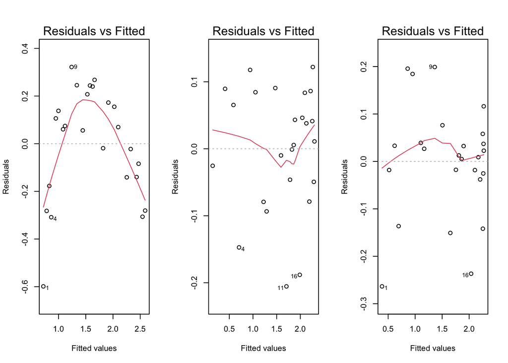

```r
windmill <- read.csv("windmill.csv")
fit1 <- lm(output ~ wind, data = windmill) # (1)
fit2 <- lm(output ~ I(1/wind), data = windmill) # (2)
fit3 <- lm(output ~ wind + I(wind^2), data = windmill) # (3)
par(mfrow=c(1,3))
plot(fit1, which = 1)
plot(fit2, which = 1)
plot(fit3, which = 1)
```

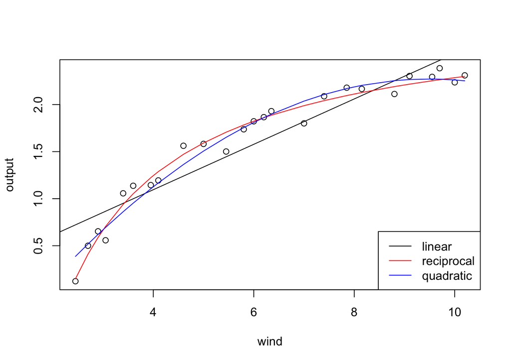

```r
par(mfrow=c(1,1))
plot(output ~ wind, data = windmill)
abline(fit1)
lines(windmill$wind, predict(fit2), col = "red")
lines(windmill$wind, predict(fit3), col = "blue")
legend("bottomright", c("linear", "reciprocal", "quadratic"), lty=1, col=c("black", "red", "blue"))
```

## Weighting

- To conduct the weighted least squares, use the `weights` argument in the `lm()` function.
- For example, the following command fit a linear model by minimizing
  $$\sum_{i=1}^n w_i (y_i - \hat\beta_0 - \hat\beta_1 x_i)^2.$$

```r
lm(output ~ I(1/wind), data = windmill, weight = c(w1, w2, [...], wn))
```

- For generalized least squares, use `lm.gls()` function in the **MASS** package.

## Polynomial Regression

- We can specify higher order terms using, e.g., `I(x^2)` (quadratic term), in the `formula`. Alternatively, one can use the `poly()` function to create polynomials.
- Note that `poly()` function creates orthogonal polynomials by default. However, they have **different** scales from the ones in the lecture note. `poly()` function creates orthogonal polynomials whose sum of squares equal 1.
- In order to obtain the raw polynomials, the argument `raw = TRUE` must be used.
- Setting `raw = TRUE` and `raw=FALSE` does not alter the fitted values, of course.
- We use the ‘Hardwood Data’ (Example 7.1, p.234), and explain strength of kraft paper (`strength`; y) by percentage of hardwood in the batch of pulp from which the paper was produced (`hardwood`; x).
- We consider four models:
  $$y = \beta_0 + \beta_1 x + \epsilon,$$
  $$y = \beta_0 + \beta_1 x + \beta_2 x^2 + \epsilon,$$
  $$y = \beta_0 + \beta_1 x + \beta_2 x^2 + \beta_3 x^3 + \epsilon,$$
  $$y = \beta_0 + \beta_1 x + \beta_2 x^2 + \beta_3 x^3 + \beta_4 x^4
  + \epsilon,$$

```r
hardwood <- read.csv("hardwood.csv")
lmfit1 <- lm(strength ~ hardwood, data=hardwood)
lmfit2 <- lm(strength ~ hardwood + I(hardwood^2), data=hardwood)
lmfit3 <- lm(strength ~ hardwood + I(hardwood^2) + I(hardwood^3), data=hardwood)
lmfit4 <- lm(strength ~ hardwood + I(hardwood^2) + I(hardwood^3) + I(hardwood^4), data=hardwood)
lmfit5 <- lm(strength ~ poly(hardwood, 4, raw = TRUE), data=hardwood)
lmfit6 <- lm(strength ~ poly(hardwood, 4), data=hardwood)
# model.matrix(lmfit4) # matrix X
# model.matrix(lmfit5)
# model.matrix(lmfit6)
model.matrix(lmfit6) |> apply(2, \(col) sum(col^2))
```

```
##        (Intercept) poly(hardwood, 4)1 poly(hardwood, 4)2 poly(hardwood, 4)3
##                 19                  1                  1                  1
## poly(hardwood, 4)4
##                  1
```

```r
data.frame(coefficients(lmfit4), coefficients(lmfit5), coefficients(lmfit6))
```

```
##               coefficients.lmfit4. coefficients.lmfit5. coefficients.lmfit6.
## (Intercept)            1.070958207          1.070958207            34.184211
## hardwood               8.049480565          8.049480565            32.302127
## I(hardwood^2)         -0.517351738         -0.517351738           -45.396250
## I(hardwood^3)          0.056574952          0.056574952           -14.573997
## I(hardwood^4)         -0.003505467         -0.003505467            -3.164712
```

```r
data.frame(predict(lmfit4), predict(lmfit5), predict(lmfit6)) |> head()
```

```
##   predict.lmfit4. predict.lmfit5. predict.lmfit6.
## 1        8.656157        8.656157        8.656157
## 2       12.154332       12.154332       12.154332
## 3       15.497025       15.497025       15.497025
## 4       21.806815       21.806815       21.806815
## 5       27.714650       27.714650       27.714650
## 6       30.535180       30.535180       30.535180
```

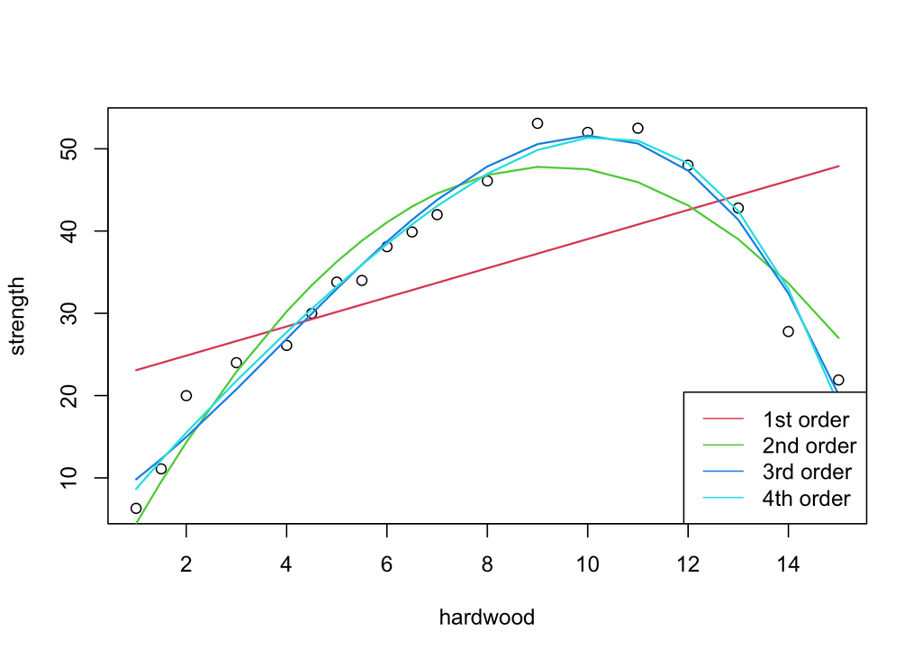

```r
plot(hardwood$hardwood, hardwood$strength, xlab="hardwood", ylab="strength")
lines(hardwood$hardwood, lmfit1$fitted.values, col=2, lwd=1.5)
lines(hardwood$hardwood, lmfit2$fitted.values, col=3, lwd=1.5)
lines(hardwood$hardwood, lmfit3$fitted.values, col=4, lwd=1.5)
lines(hardwood$hardwood, lmfit4$fitted.values, col=5, lwd=1.5)
legend("bottomright", c("1st order", "2nd order", "3rd order", "4th order"), col=c(2,3,4,5), lty=1)
```

### Piecewise linear regression

We use the ‘Voltage Drop Data’ (Example 7.2, p.238), where we denote `time` as $x$ and `voltage drop` as $y$. We wish to fit a piecewise linear model
$$y = \beta_0 + \beta_1 x + \beta_2 (x-6.5)_{+} + \beta_3 (x-13)_+ +
\epsilon,$$
where $t_+ = t$ if $t>0$ and 0 otherwise.

```r
library(readxl)
VD <- read_xls("Voltage_Drop.xls")
colnames(VD) <- c("obs","time","voltage")
head(VD)
```

```
## # A tibble: 6 × 3
##     obs  time voltage
##   <dbl> <dbl>   <dbl>
## 1     1   0      8.33
## 2     2   0.5    8.23
## 3     3   1      7.17
## 4     4   1.5    7.14
## 5     5   2      7.31
## 6     6   2.5    7.6
```

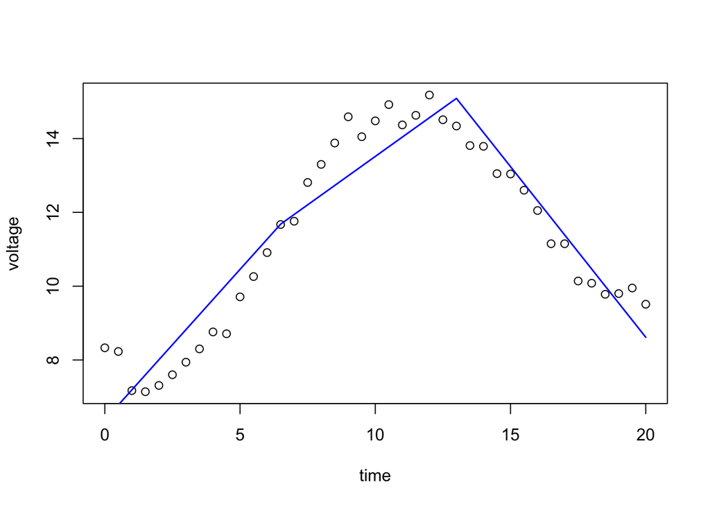

```r
hinge <- \(x,t) return((x - t)*(x > t)) # returns (x-t)_+
fit.pl <- lm(voltage ~ time  + hinge(time, 6.5)  + hinge(time, 13), data=VD)
# model.matrix(fit.pl)
plot(voltage ~ time, data = VD)
lines(VD$time, fit.pl$fitted.values, col="blue", lwd=1.5)
```

# Model Adequacy Checking and Diagnostics (Ch 4, 6)

## Residuals

|  | Eqn | Function |
| --- | --- | --- |
| Residuals | $e_i = y_i - \hat{y}_i$ | `residuals()` |
| Standardized residuals | $d_i = \frac{e_i}{\sqrt{MS_E}}$ |  |
| Studentized residuals | $r_i = \frac{e_i}{\sqrt{MS_E(1-h_{ii})}}$ | `rstandard()` |
| R-Student | $t_i = \frac{e_i}{\sqrt{S_{(i)}^2(1-h_{ii})}}$ | `rstudent()` |
| PRESS (**PRE**dictive **S**um of **S**quares) residuals | $e_{(i)} = y_i - \hat{y}_{(i)} = \frac{e_i}{1-h_{ii}}$ | `rstandard()` with `type = "predictive"` |

- $S_{(i)}^2$ is an estimate of $\sigma^2$ obtained from fitting the model after omitting the $i$th observation. Refer to p.140 of the textbook for details.

> **Caution: Following the notations in the lecture note, `rstandard` computes Studentized residuals, not standardized residuals!! `rstudent` computes R-Student.**

```r
lmfit.full <- lm(time ~ case + distance, data=deliver)
# ?influence.measures
e <- residuals(lmfit.full) # residuals
d <- residuals(lmfit.full)/summary(lmfit.full)$sigma # standardized residuals
r <- rstandard(lmfit.full) # *Studentized* residuals
t <- rstudent(lmfit.full)  # R-Student
press <- rstandard(lmfit.full, type="predictive") # PRESS residuals
data.frame(residuals=e,
           standardized=d,
           studentized=r,
           Rstudent=t,
           PRESS = press)
```

```
##     residuals standardized studentized    Rstudent       PRESS
## 1  -5.0280843  -1.54260631 -1.62767993 -1.69562881 -5.59796734
## 2   1.1463854   0.35170879  0.36484267  0.35753764  1.23360321
## 3  -0.0497937  -0.01527661 -0.01609165 -0.01572177 -0.05524867
## 4   4.9243539   1.51078203  1.57972040  1.63916491  5.38401290
## 5  -0.4443983  -0.13634053 -0.14176094 -0.13856493 -0.48043610
## 6  -0.2895743  -0.08884082 -0.09080847 -0.08873728 -0.30254339
## 7   0.8446235   0.25912883  0.27042496  0.26464769  0.91986749
## 8   1.1566049   0.35484408  0.36672118  0.35938983  1.23532680
## 9   7.4197062   2.27635117  3.21376278  4.31078012 14.78889824
## 10  2.3764129   0.72907878  0.81325432  0.80677584  2.95682585
## 11  2.2374930   0.68645843  0.71807970  0.70993906  2.44837821
## 12 -0.5930409  -0.18194377 -0.19325733 -0.18897451 -0.66908638
## 13  1.0270093   0.31508443  0.32517935  0.31846924  1.09387183
## 14  1.0675359   0.32751789  0.34113547  0.33417725  1.15815364
## 15  0.6712018   0.20592338  0.21029137  0.20566324  0.69997845
## 16 -0.6629284  -0.20338513 -0.22270023 -0.21782566 -0.79482144
## 17  0.4363603   0.13387449  0.13803929  0.13492400  0.46393280
## 18  3.4486213   1.05803019  1.11295196  1.11933065  3.81594602
## 19  1.7931935   0.55014821  0.57876634  0.56981420  1.98460588
## 20 -5.7879699  -1.77573772 -1.87354643 -1.99667657 -6.44313971
## 21 -2.6141789  -0.80202492 -0.87784258 -0.87308697 -3.13179171
## 22 -3.6865279  -1.13101946 -1.44999541 -1.48962473 -6.05913500
## 23 -4.6075679  -1.41359270 -1.44368977 -1.48246718 -4.80585779
## 24 -4.5728535  -1.40294240 -1.49605875 -1.54221512 -5.20001871
## 25 -0.2125839  -0.06522033 -0.06750861 -0.06596332 -0.22776283
```

- Observation #9 has a large residual, standardized residual, Studentized residual, and R-Student. Hence, the model does not fit this point well.
- Observations #9 and #22 have large PRESS residuals. This means that the model does not provide good predictions at those observations.

## Residual Plots

- Linearity, equal variance: $e_i$ vs $\hat{y}_i$

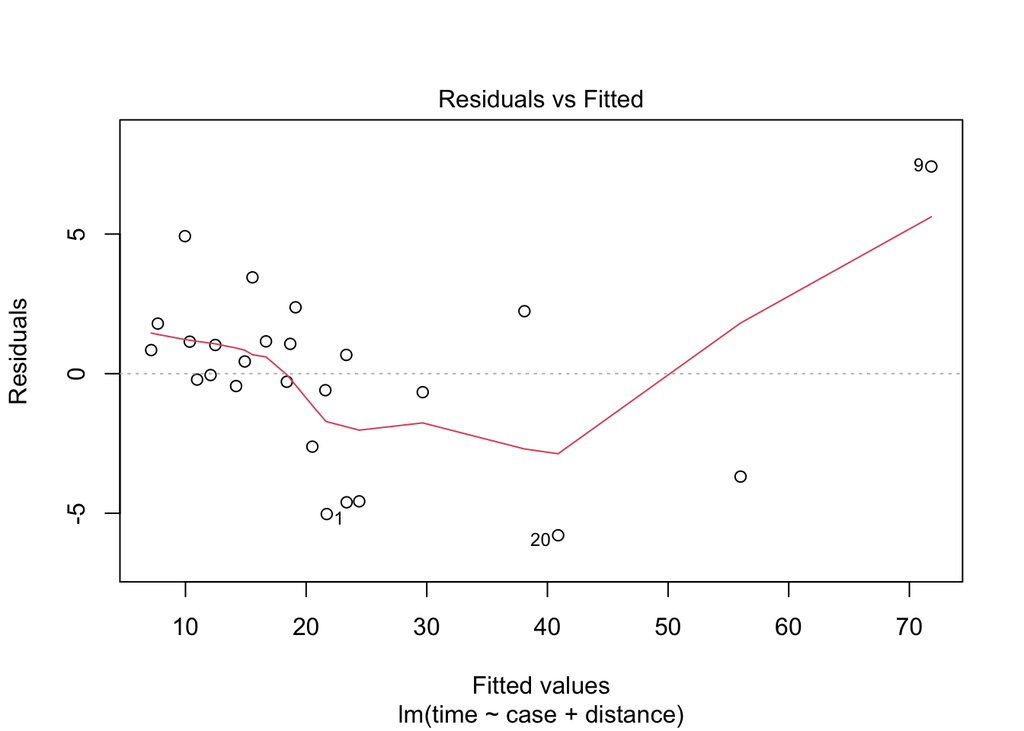

```r
# ?plot.lm
plot(lmfit.full, which = 1)
```

- Normality: Normal probability plot
  - In the following plot, standardized residual (y-axis) refers to $r_i = \frac{e_i}{\sqrt{MS_E(1-h_{ii})}}$, i.e., **Studentized residual** in the lecture note.

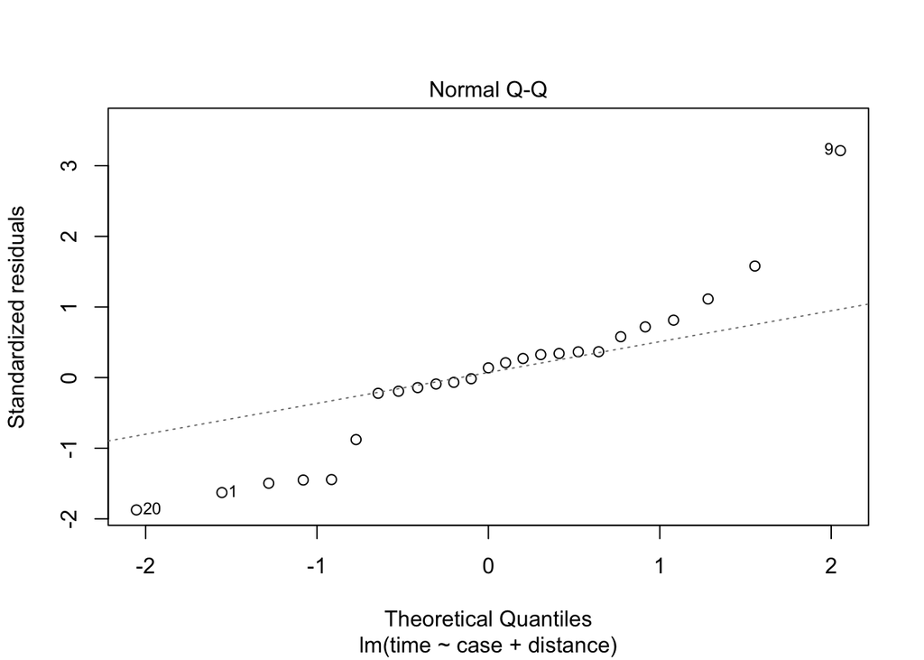

```r
plot(lmfit.full, which = 2)
```

- Independence: residual vs time

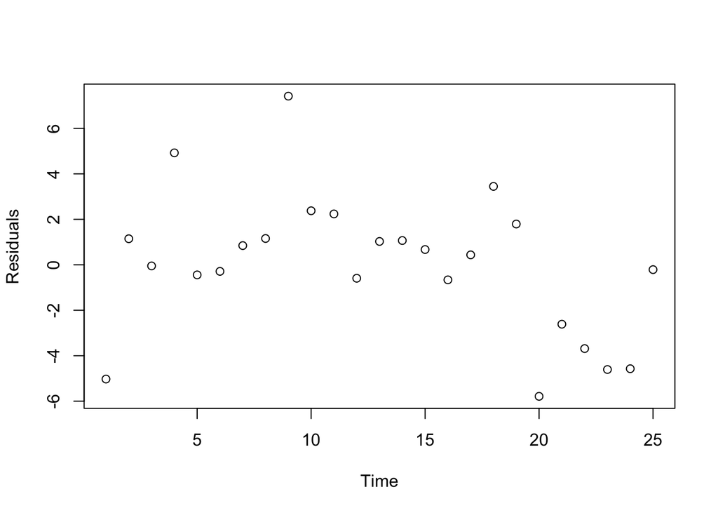

```r
plot(1:25, residuals(lmfit.full),
     xlab = "Time", ylab = "Residuals")
```

## Tests

### Durbin–Watson test

- Test for independence

```r
#install.packages("lmtest")
library(lmtest)
dwtest(time ~ case + distance, data=deliver, alternative="two.sided")
```

```
##
##  Durbin-Watson test
##
## data:  time ~ case + distance
## DW = 1.1696, p-value = 0.02403
## alternative hypothesis: true autocorrelation is not 0
```

- At $\alpha = 0.05$, we reject the null hypothesis and conclude that the autocorrelation is not zero, i.e., errors are **not** independent.

### Lack of Fit test

- Test for the lack of fit of a regression model
  - $H_0: E(y\mid x) = \beta_0 + \beta_1 x$ vs $H_1: \text{not } H_0$

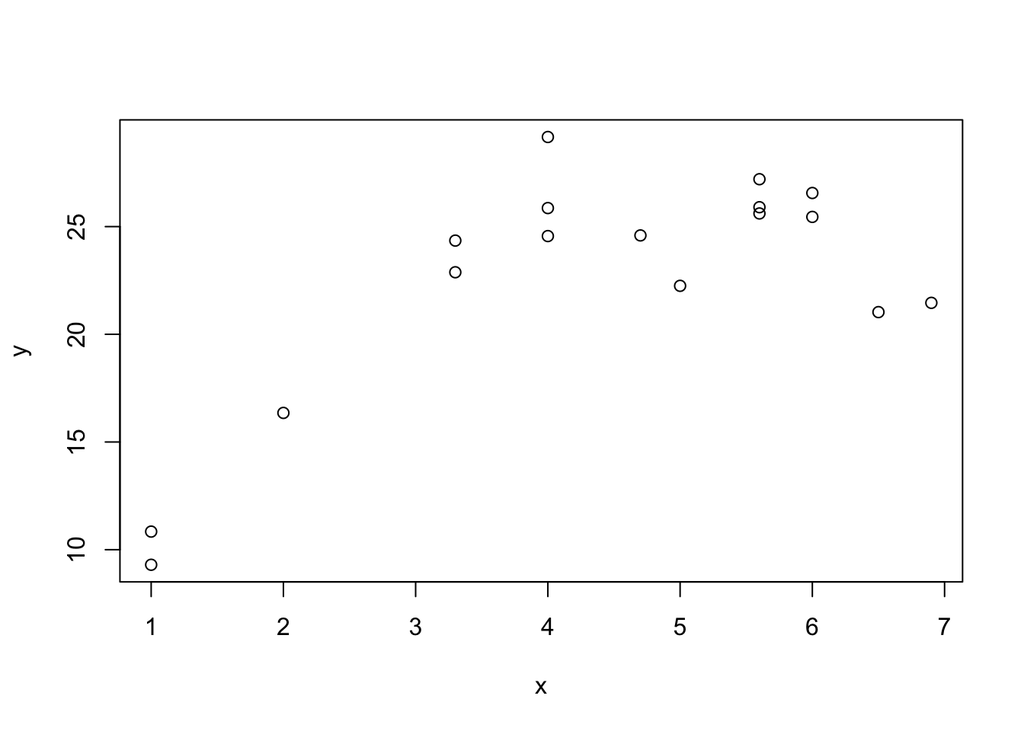

```r
x <- c(1.0, 1.0, 2.0, 3.3, 3.3, 4.0, 4.0, 4.0, 4.7, 5.0, 5.6, 5.6, 5.6, 6.0, 6.0, 6.5, 6.9)
y <- c(10.84, 9.30, 16.35, 22.88, 24.35, 24.56, 25.86, 29.16, 24.59, 22.25, 25.90, 27.20, 25.61, 25.45, 26.56, 21.03, 21.46)
plot(x, y)
```

```r
anova(lm(y ~ 1), lm(y ~ x), lm(y ~ factor(x)))
```

```
## Analysis of Variance Table
##
## Model 1: y ~ 1
## Model 2: y ~ x
## Model 3: y ~ factor(x)
##   Res.Df    RSS Df Sum of Sq       F    Pr(>F)
## 1     16 487.61
## 2     15 250.13  1    237.48 106.814 1.721e-05 ***
## 3      7  15.56  8    234.57  13.188  0.001389 **
## ---
## Signif. codes:  0 '***' 0.001 '**' 0.01 '*' 0.05 '.' 0.1 ' ' 1
```

- p-value is 0.0014, and we reject the null hypothesis: the simple linear regression model does **not** adequately describe the data.
- An ANOVA table can be constructed.

| Source of Variation | SS | DF | MS | $F_0$ |
| --- | --- | --- | --- | --- |
| Regression | 237.48 | 1 | 237.48 |  |
| Residual | 250.13 | 15 | 16.68 |  |
| (LoF) | 234.57 | 8 | 29.32 | 13.188 |
| (PE) | 15.56 | 7 | 2.22 |  |
| Total | 487.61 | 16 |  |  |

## Leverage and Measures of Influence

- Diagonal elements $h_{ii}$ of the hat matrix is a measure of the distance of the $i$th observation from the center of the $x$-space. Use the `hatvalues` function.
- Decision rule: if $h_{ii} > 2p/n$, the $i$th observation can be considered as a **leverage point**. In the ‘Delivery time data,’ observations #9 and #22 are leverage points.

```r
hatvalues(lmfit.full) # h_ii
```

```
##          1          2          3          4          5          6          7
## 0.10180178 0.07070164 0.09873476 0.08537479 0.07501050 0.04286693 0.08179867
##          8          9         10         11         12         13         14
## 0.06372559 0.49829216 0.19629595 0.08613260 0.11365570 0.06112463 0.07824332
##         15         16         17         18         19         20         21
## 0.04111077 0.16594043 0.05943202 0.09626046 0.09644857 0.10168486 0.16527689
##         22         23         24         25
## 0.39157522 0.04126005 0.12060826 0.06664345
```

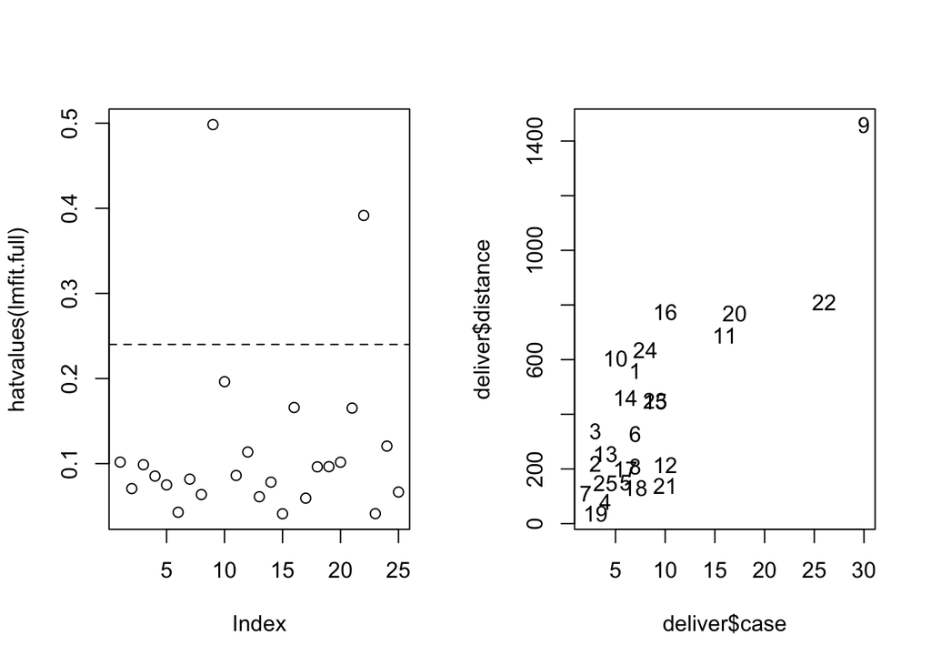

```r
par(mfrow = c(1,2))
plot(hatvalues(lmfit.full))
abline(h = 2*3/nrow(deliver), lty = 2)
plot(deliver$case, deliver$distance, pch = NA)
text(deliver$case, deliver$distance, labels = 1:25)
```

```r
which(hatvalues(lmfit.full) > 2*3/nrow(deliver))
```

```
##  9 22
##  9 22
```

- Measures of influence
  - Cook’s $D$: `cooks.distance(lmfit.full)`
  - DFFITS: `dffits(lmfit.full)`

```r
cooks.distance(lmfit.full)
```

```
##            1            2            3            4            5            6
## 1.000921e-01 3.375704e-03 9.455785e-06 7.764718e-02 5.432217e-04 1.231067e-04
##            7            8            9           10           11           12
## 2.171604e-03 3.051135e-03 3.419318e+00 5.384516e-02 1.619975e-02 1.596392e-03
##           13           14           15           16           17           18
## 2.294737e-03 3.292786e-03 6.319880e-04 3.289086e-03 4.013419e-04 4.397807e-02
##           19           20           21           22           23           24
## 1.191868e-02 1.324449e-01 5.086063e-02 4.510455e-01 2.989892e-02 1.023224e-01
##           25
## 1.084694e-04
```

```r
which(cooks.distance(lmfit.full) > 1) # Decision rule: D_i > 1 -> i is a influence point
```

```
## 9
## 9
```

```r
dffits(lmfit.full) # |DFFITS| large -> influence point
```

```
##            1            2            3            4            5            6
## -0.570850478  0.098618619 -0.005203676  0.500801817 -0.039458989 -0.018779374
##            7            8            9           10           11           12
##  0.078990030  0.093760764  4.296080927  0.398713071  0.217953207 -0.067670223
##           13           14           15           16           17           18
##  0.081259033  0.097362643  0.042584374 -0.097159801  0.033915978  0.365309285
##           19           20           21           22           23           24
##  0.186167873 -0.671771402 -0.388501185 -1.195036104 -0.307538544 -0.571139627
##           25
## -0.017626149
```

# Indicator Variables (Ch 8)

- We consider ‘Tool Life Data’ (Example 8.1, p.270). There are two types of tools, A and B. We fit the model
  $${\tt hour} = \beta_0 + \beta_1 {\tt rpm} + \beta_2 x_2 + \epsilon$$
  where $x_2 = 0$ if the observation is from type A, and $x_2=1$ if the observation is from type B. Hence, for type A,
  $${\tt hour} = \beta_0 + \beta_1 {\tt rpm} + \epsilon,$$
  and for type B,
  $${\tt hour} = (\beta_0 + \beta_2) + \beta_1 {\tt rpm} + \epsilon$$

```r
library(readxl)
TL <- read_xls("Tool_Life.xls")
colnames(TL) <- c("obs","hours","rpm","type")
head(TL)
```

```
## # A tibble: 6 × 4
##     obs hours   rpm type
##   <dbl> <dbl> <dbl> <chr>
## 1     1  18.7   610 A
## 2     2  14.5   950 A
## 3     3  17.4   720 A
## 4     4  14.5   840 A
## 5     5  13.4   980 A
## 6     6  24.4   530 A
```

```r
tail(TL)
```

```
## # A tibble: 6 × 4
##     obs hours   rpm type
##   <dbl> <dbl> <dbl> <chr>
## 1    15  33.5   760 B
## 2    16  35.6   590 B
## 3    17  26.1   910 B
## 4    18  36.8   650 B
## 5    19  35.0   810 B
## 6    20  43.7   500 B
```

```r
TL$type <- factor(TL$type)
lmfit.TL <- lm(hours ~ rpm + type, data = TL)
summary(lmfit.TL)
```

```
##
## Call:
## lm(formula = hours ~ rpm + type, data = TL)
##
## Residuals:
##     Min      1Q  Median      3Q     Max
## -7.6255 -1.6308  0.0612  2.2218  5.5044
##
## Coefficients:
##              Estimate Std. Error t value Pr(>|t|)
## (Intercept) 35.208726   3.738882   9.417 3.71e-08 ***
## rpm         -0.024557   0.004865  -5.048 9.92e-05 ***
## typeB       15.235474   1.501220  10.149 1.25e-08 ***
## ---
## Signif. codes:  0 '***' 0.001 '**' 0.01 '*' 0.05 '.' 0.1 ' ' 1
##
## Residual standard error: 3.352 on 17 degrees of freedom
## Multiple R-squared:  0.8787, Adjusted R-squared:  0.8645
## F-statistic:  61.6 on 2 and 17 DF,  p-value: 1.627e-08
```

- When `lm()` encounters a factor variable with two levels, it creates a new variable based on the second level.
- Similarly, variable based on the second and third levels are created when treating a factor variable with three levels.

```r
TL$type |> levels()
```

```
## [1] "A" "B"
```

```r
TL$type2 <- factor(TL$type, levels = c("B", "A"))
lm(hours ~ rpm + type2, data = TL) |> summary()
```

```
##
## Call:
## lm(formula = hours ~ rpm + type2, data = TL)
##
## Residuals:
##     Min      1Q  Median      3Q     Max
## -7.6255 -1.6308  0.0612  2.2218  5.5044
##
## Coefficients:
##               Estimate Std. Error t value Pr(>|t|)
## (Intercept)  50.444200   3.818266  13.211 2.28e-10 ***
## rpm          -0.024557   0.004865  -5.048 9.92e-05 ***
## type2A      -15.235474   1.501220 -10.149 1.25e-08 ***
## ---
## Signif. codes:  0 '***' 0.001 '**' 0.01 '*' 0.05 '.' 0.1 ' ' 1
##
## Residual standard error: 3.352 on 17 degrees of freedom
## Multiple R-squared:  0.8787, Adjusted R-squared:  0.8645
## F-statistic:  61.6 on 2 and 17 DF,  p-value: 1.627e-08
```

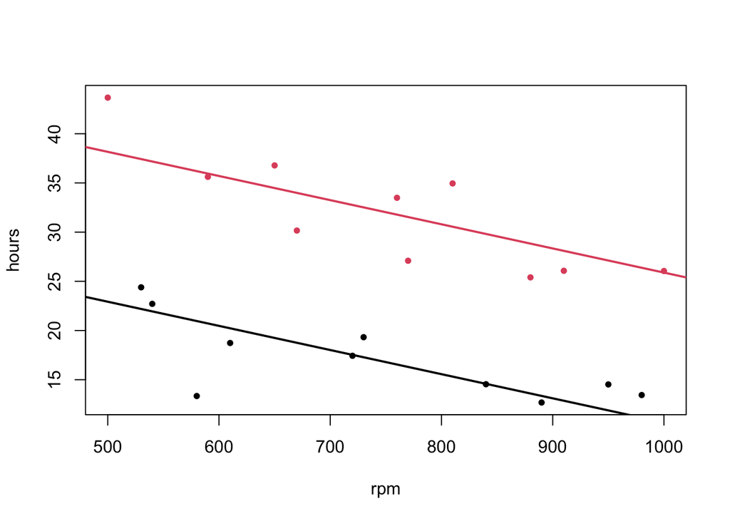

```r
plot(hours ~ rpm, data=TL, col=as.integer(type),
     xlab="rpm", ylab="hours", pch=20)
abline(a=coefficients(lmfit.TL)[1], b=coefficients(lmfit.TL)[2], col=1, lwd=2)
abline(a=sum(coefficients(lmfit.TL)[c(1,3)]),
       b=coefficients(lmfit.TL)[2], col=2, lwd=2)
```

- We next fit the regression model with interaction,
  $${\tt hour} = \beta_0 + \beta_1 {\tt rpm} + \beta_2 x_2 + \beta_3{\tt
  rpm}\times x_2 + \epsilon,$$

```r
# (1) and (2) are equivalent
lm(hours ~ rpm*type, data = TL) # (1)
lm(hours ~ rpm + type + rpm:type, data = TL) # (2)
```

## Regression Approach to Analysis of Variance

- single-factor ANOVA model:
  $$y_{ij} = \mu + \tau_i + \epsilon_{ij},\quad i=1,\dots,a;~j=1,\dots,n$$
  with $\sum_{i=1}^a \tau_i = 0$. Suppose that $a=3$ and $n=2$.
- Above model is equivalent to the following linear regression model:
  $$\begin{bmatrix}y_{11}\\y_{12}\\y_{21}\\y_{22}\\y_{31}\\y_{32}\end{bmatrix}
  = \begin{bmatrix}1&1&0\\ 1&1&0\\
  1&0&1\\1&0&1\\1&-1&-1\\1&-1&-1\\
  \end{bmatrix}
  \begin{bmatrix}\mu\\\tau_1\\\tau_2 \end{bmatrix} +
  \boldsymbol{\epsilon}.$$
- Therefore, $H_0: \tau_1 = \tau_2 = \tau_3 = 0$ can be tested using the model significance test ($F_0 = MS_R/MS_E$).
- $\hat{\mu}$, $\hat{\tau}_1$, $\hat{\tau}_2$, $\hat{\tau}_3$ can be easily derived.

```r
### Example
x1 <- c(1,1,0,0,-1,-1)
x2 <- c(0,0,1,1,-1,-1)
lm(y ~ x1 + x2) |> summary()
```

### References

- *Introduction to Linear Regression Analysis*, 6th Edition, by Montgomery, Peck & Vining, Wiley (2021).
- *An Introduction to Statistical Learning*, 2nd Edition, by James, Witten, Hastie & Tibshirani, Springer (2021).